# Análise Comparativa da Classificação de Robson

- Mostrar o código
- Esconder o código
- Ver o código fonte

Adolescentes vs. Adultas — Coorte HC-FMUSP (1995–2017)

Autor

Letícia Schimidt Arruda

Data de Publicação

23 de maio de 2026

## Critérios de Elegibilidade — Conforme Dissertação (Seção 3.3)

Esta seção documenta formalmente os critérios de inclusão e exclusão aplicados à base de dados, em correspondência direta com a Seção 3.3 do manuscrito da dissertação. A implementação computacional desses critérios está no chunk `filtragem-dados`, abaixo.

**Critérios de Inclusão:**

- Gestantes com idade entre 11 e 19 anos (adolescentes) ou entre 20 e 34 anos (adultas), com prontuário preenchido contendo dados clínicos e obstétricos;
- Gestação única (feto único);
- Classificação de Robson pertencente aos Grupos 1, 2, 3, 4, 5, 6, 7, 9 ou 10;
- Parto ocorrido após 22 semanas completas de gestação;
- Dados preenchidos sobre a assistência ao parto (campo `tipo_parto` não nulo).

**Critérios de Exclusão:**

- Idade materna fora do intervalo 11–34 anos (excluindo, portanto, gestantes com 35 anos ou mais, que compõem grupo de análise separado no SPSS);
- Classificação de Robson 8 (não presente na base, mas filtro explícito mantido por rastreabilidade);
- Gestação múltipla — observação: a coluna de gestação gemelar/múltipla não foi localizada na base Excel com nomenclatura explícita; o filtro de Robson (que exclui o Grupo 8, específico para gestações múltiplas) garante implicitamente a exclusão de multifetais classificados por Robson; casos com Robson ausente/inválido também são excluídos;
- Abortamento: partos com idade gestacional inferior a 22 semanas ou peso do recém-nascido inferior a 500 g (critério aplicado via `ig_parto`).

**AvisoNota sobre a coluna ig_parto**

A variável `ig_parto` apresenta valores zero (0.0) que representam dado ausente/não preenchido — não um parto com zero semanas. O filtro de IG ≥ 22 semanas é aplicado apenas quando a coluna possui valor válido (> 0); registros ausentes ou zerados são mantidos por precaução para não inflar as perdas.

# Introdução

Este documento apresenta o **pipeline completo de análise** da dissertação de mestrado que investiga as diferenças nas vias de parto entre adolescentes e adultas, utilizando a **Classificação de Robson** como ferramenta de estratificação.

**NotaObjetivos Específicos**

# 1 Carregamento e Preparação dos Dados

## 1.1 Importação da Base de Dados

A base de dados contém registros obstétricos do Hospital das Clínicas da FMUSP referentes ao período de 1995 a 2017.

**Mostrar código**

```r
# Fonte canônica para análise §3.3 — N esperado após filtros: 6.650
dados <- read_excel(
    here("data", "raw", "BD_completo_corrigido_06-04-2026.xlsx"),
    sheet = "Sheet1"
)

cat("Dimensões da base bruta:", nrow(dados), "registros ×", ncol(dados), "variáveis\n")
```

```
Dimensões da base bruta: 8676 registros × 102 variáveis
```

## 1.2 Critérios de Elegibilidade e Filtros

Os seguintes critérios de inclusão foram aplicados:

- **Idade:** entre 11 e 34 anos
- **Tipo de parto:** registrado (não nulo)
- **Classificação de Robson:** registrada e válida (Grupos 1–10, excluindo Grupo 8)

**Mostrar código**

```r
# =============================================================================
# CRITÉRIOS DE ELEGIBILIDADE — Seção 3.3 da dissertação
#
# INCLUSÃO:
#   - Idade 11–34 anos, com tipo_parto e idade preenchidos
#   - Gestação única (garantida via Robson: Grupo 8 = múltiplas, excluído)
#   - Robson válido nos Grupos 1, 2, 3, 4, 5, 6, 7, 9 ou 10 (exclui 8 explicitamente)
#   - Parto após 22 semanas (ig_parto ≥ 22; ig_parto == 0 é dado ausente)
#   - Dados de assistência ao parto presentes (tipo_parto não nulo)
#
# EXCLUSÃO:
#   - Idade fora de 11–34 anos
#   - Robson 8 (gestação múltipla) ou Robson ausente/inválido
#   - IG < 22 semanas (abortamento), quando a informação estiver disponível
# =============================================================================

n_total_bruto <- nrow(dados)

# Passo 1: Excluir registros sem tipo_parto ou sem idade
dados_s1 <- dados %>% filter(!is.na(tipo_parto), !is.na(idade))
n_excl_s1 <- n_total_bruto - nrow(dados_s1)

# Passo 2: Filtrar por faixa etária elegível (11–34 anos)
dados_s2 <- dados_s1 %>% filter(idade >= 11 & idade <= 34)
n_excl_s2 <- nrow(dados_s1) - nrow(dados_s2)

# Passo 3: Padronizar e filtrar Robson (excluir Robson 8, ausente ou inválido)
dados_s3 <- dados_s2 %>%
    mutate(
        Robson_cat = case_when(
            grepl("^10", as.character(Robson)) ~ "10",
            grepl("^1", as.character(Robson)) ~ "1",
            grepl("^2", as.character(Robson)) ~ "2",
            grepl("^3", as.character(Robson)) ~ "3",
            grepl("^4", as.character(Robson)) ~ "4",
            grepl("^5", as.character(Robson)) ~ "5",
            grepl("^6", as.character(Robson)) ~ "6",
            grepl("^7", as.character(Robson)) ~ "7",
            grepl("^9", as.character(Robson)) ~ "9",
            TRUE ~ NA_character_ # inclui Robson 8 e qualquer valor inválido
        )
    ) %>%
    filter(!is.na(Robson_cat))
n_excl_s3 <- nrow(dados_s2) - nrow(dados_s3)

# Passo 4: Filtrar por IG ≥ 22 semanas
# Nota: ig_parto == 0 representa dado ausente (não parto com 0 semanas).
# O filtro é aplicado SOMENTE quando a coluna tem valor válido (> 0).
# ig_best usa ig_parto como primário; quando ausente, usa ig_parto2 como fallback.
# Registros com ig_best NA ou == 0 são mantidos (dado não registrado, não abortamento).
dados_s4 <- dados_s3 %>%
    mutate(
        ig_best = case_when(
            !is.na(ig_parto) & ig_parto > 0 ~ ig_parto,
            is.na(ig_parto) & !is.na(ig_parto2) & ig_parto2 > 0 ~ ig_parto2,
            TRUE ~ NA_real_
        )
    ) %>%
    filter(is.na(ig_best) | ig_best >= 22)
n_excl_s4 <- nrow(dados_s3) - nrow(dados_s4)
n_ig_desconhecida <- sum(is.na(dados_s4$ig_best))

# Passo 5: Acrescentar variáveis derivadas para análise
dados_analise <- dados_s4 %>%
    mutate(
        # Classificação por faixa etária
        faixa_etaria = case_when(
            idade >= 11 & idade <= 15 ~ "Adolescentes precoces (11-15)",
            idade >= 16 & idade <= 19 ~ "Adolescentes tardias (16-19)",
            idade >= 20 & idade <= 34 ~ "Adultas (20-34)"
        ),
        faixa_etaria_f = factor(faixa_etaria, levels = c(
            "Adolescentes precoces (11-15)",
            "Adolescentes tardias (16-19)",
            "Adultas (20-34)"
        )),
        # Grupo comparativo binário
        grupo_comparativo = ifelse(idade <= 19, "Adolescentes", "Adultas"),
        # Descrição da via de parto
        tipo_parto_desc = case_when(
            tipo_parto == 1 ~ "Normal (Vaginal Espontâneo)",
            tipo_parto == 2 ~ "Cesárea",
            tipo_parto == 3 ~ "Fórcipe (Instrumental)"
        ),
        # Robson como fator ordenado
        Robson_cat_f = factor(as.numeric(Robson_cat),
            levels = c(1, 2, 3, 4, 5, 6, 7, 9, 10),
            labels = paste("Grupo", c(1, 2, 3, 4, 5, 6, 7, 9, 10))
        )
    )

# ── Validação §3.3: N esperado após todos os filtros ─────────────────────────
# N esperado: 6.650 (538 precoces, 829 tardias, 5.283 adultas)
# ig_best usa ig_parto como primário e ig_parto2 como fallback; 2 registros têm
# ig_parto=NA mas ig_parto2 < 22 semanas e são excluídos corretamente.
n_final_esperado <- 6650L
if (nrow(dados_analise) != n_final_esperado) {
    warning(sprintf(
        "ATENÇÃO §3.3: N obtido = %d, mas N esperado = %d. Verifique os filtros.",
        nrow(dados_analise), n_final_esperado
    ))
} else {
    cat(sprintf("OK §3.3: N = %d (conforme esperado).\n", nrow(dados_analise)))
}
```

```
OK §3.3: N = 6650 (conforme esperado).
```

```
╔══════════════════════════════════════════════════════════════════════╗
```

```
║           DIAGRAMA DE FLUXO DE ELEGIBILIDADE (CONSORT)             ║
```

```
╠══════════════════════════════════════════════════════════════════════╣
```

```
║  Base completa (bruta):                              N =   8676    ║
```

```
║                                                                      ║
```

```
║  (−) Sem tipo_parto ou sem idade registrados:        n =    376    ║
```

```
║      → N após exclusão:                                    8300    ║
```

```
║                                                                      ║
```

```
║  (−) Idade fora do intervalo 11–34 anos:             n =   1469    ║
```

```
║      → N após exclusão:                                    6831    ║
```

```
║                                                                      ║
```

```
║  (−) Robson ausente, inválido ou Grupo 8:            n =    168    ║
```

```
║      → N após exclusão:                                    6663    ║
```

```
║                                                                      ║
```

```
║  (−) IG < 22 semanas (abortamento):                  n =     13    ║
```

```
║      (registros com IG desconhecida, mantidos):      n =    944    ║
```

```
║      → N após exclusão:                                    6650    ║
```

```
║                                                                      ║
```

```
╠══════════════════════════════════════════════════════════════════════╣
```

```
║  N FINAL PARA ANÁLISE:                               N =   6650    ║
```

```
║    Adolescentes precoces (11–15 anos):               n =    538    ║
```

```
║    Adolescentes tardias  (16–19 anos):               n =    829    ║
```

```
║    Adultas               (20–34 anos):               n =   5283    ║
```

```
╚══════════════════════════════════════════════════════════════════════╝
```

**Mostrar código**

```r
# Resumo da amostra final
resumo <- dados_analise %>%
    count(faixa_etaria_f, name = "n") %>%
    mutate(pct = round(n / sum(n) * 100, 1))

cat("Total de registros para análise:", nrow(dados_analise), "\n\n")
```

```
Total de registros para análise: 6650
```

**Mostrar código**

```r
resumo %>%
    rename(`Faixa Etária` = faixa_etaria_f, `N` = n, `%` = pct) %>%
    kable(caption = "Distribuição da amostra por faixa etária") %>%
    kable_styling(bootstrap_options = c("striped", "hover"), full_width = FALSE)
```

Distribuição da amostra por faixa etária

| Faixa Etária | N | % |
| --- | --- | --- |
| Adolescentes precoces (11-15) | 538 | 8.1 |
| Adolescentes tardias (16-19) | 829 | 12.5 |
| Adultas (20-34) | 5283 | 79.4 |

**Mostrar código**

```r
# =============================================================================
# VALIDAÇÃO §3.3 — N total esperado: 6.650
# Conforme filtro definitivo da seção 3.3 da dissertação:
#   - Idade 11-34 anos, tipo_parto não nulo, Robson válido (1-7,9,10),
#     IG ≥ 22 quando registrada (IG=0 = dado ausente, mantido).
# =============================================================================
N_ESPERADO <- 6650L
N_OBTIDO   <- nrow(dados_analise)

if (N_OBTIDO == N_ESPERADO) {
    cat(sprintf(
        "VALIDAÇÃO OK: nrow(dados_analise) = %d (esperado: %d)\n",
        N_OBTIDO, N_ESPERADO
    ))
} else {
    stop(sprintf(
        "VALIDAÇÃO FALHOU: N obtido = %d, N esperado = %d. Revisar filtro §3.3.",
        N_OBTIDO, N_ESPERADO
    ))
}
```

```
VALIDAÇÃO OK: nrow(dados_analise) = 6650 (esperado: 6650)
```

**Mostrar código**

```r
# Distribuição esperada por faixa (ref. §3.3):
#   precoces (11-15): 538  |  tardias (16-19): 829  |  adultas (20-34): 5.283
cat("\nDistribuição por faixa etária (filtro §3.3):\n")
```

```
Distribuição por faixa etária (filtro §3.3):
```

**Mostrar código**

```r
cat(sprintf("  Adolescentes precoces (11-15): %d\n",
    sum(dados_analise$faixa_etaria == "Adolescentes precoces (11-15)", na.rm = TRUE)))
```

```
  Adolescentes precoces (11-15): 538
```

**Mostrar código**

```r
cat(sprintf("  Adolescentes tardias  (16-19): %d\n",
    sum(dados_analise$faixa_etaria == "Adolescentes tardias (16-19)", na.rm = TRUE)))
```

```
  Adolescentes tardias  (16-19): 829
```

**Mostrar código**

```r
cat(sprintf("  Adultas               (20-34): %d\n",
    sum(dados_analise$faixa_etaria == "Adultas (20-34)", na.rm = TRUE)))
```

```
  Adultas               (20-34): 5283
```

**DicaNota sobre a Classificação de Robson**

A Classificação de Robson divide as gestantes em 10 grupos mutuamente exclusivos com base em características obstétricas (paridade, apresentação fetal, idade gestacional, cicatriz uterina prévia e início do trabalho de parto). Os **Grupos 4 e 5** (multíparas) naturalmente não contêm adolescentes precoces, e os **Grupos 6, 7 e 9** apresentam números muito reduzidos de adolescentes.

# 2 Objetivo 1: Perfil Sociodemográfico

## 2.1 Distribuição Etária

**Mostrar código**

```r
sumario_idade <- dados_analise %>%
    group_by(faixa_etaria_f) %>%
    summarise(
        N = n(),
        `Média` = round(mean(idade, na.rm = TRUE), 1),
        `DP` = round(sd(idade, na.rm = TRUE), 1),
        `Mín` = min(idade, na.rm = TRUE),
        `Mediana` = median(idade, na.rm = TRUE),
        `Máx` = max(idade, na.rm = TRUE),
        .groups = "drop"
    )

sumario_idade %>%
    rename(`Faixa Etária` = faixa_etaria_f) %>%
    kable() %>%
    kable_styling(bootstrap_options = c("striped", "hover"), full_width = FALSE)
```

Tabela 1: Estatísticas descritivas da idade por faixa etária

| Faixa Etária | N | Média | DP | Mín | Mediana | Máx |
| --- | --- | --- | --- | --- | --- | --- |
| Adolescentes precoces (11-15) | 538 | 14.4 | 0.8 | 11 | 15 | 15 |
| Adolescentes tardias (16-19) | 829 | 16.6 | 0.6 | 16 | 16 | 19 |
| Adultas (20-34) | 5283 | 27.0 | 4.1 | 20 | 27 | 34 |

## 2.2 Escolaridade

**Mostrar código**

```r
tab_escol <- dados_analise %>%
    filter(!is.na(escolaridade_cat)) %>%
    count(faixa_etaria_f, escolaridade_cat) %>%
    group_by(faixa_etaria_f) %>%
    mutate(
        pct = round(n / sum(n) * 100, 1),
        n_pct = paste0(n, " (", pct, "%)")
    ) %>%
    select(faixa_etaria_f, escolaridade_cat, n_pct) %>%
    pivot_wider(names_from = faixa_etaria_f, values_from = n_pct, values_fill = "0 (0%)")

tab_escol %>%
    rename(`Escolaridade` = escolaridade_cat) %>%
    kable() %>%
    kable_styling(bootstrap_options = c("striped", "hover"), full_width = FALSE)
```

Tabela 2: Distribuição da escolaridade por faixa etária — n (%)

| Escolaridade | Adolescentes precoces (11-15) | Adolescentes tardias (16-19) | Adultas (20-34) |
| --- | --- | --- | --- |
| 1 | 1 (0.2%) | 1 (0.1%) | 45 (1%) |
| 2 | 379 (74%) | 286 (37.1%) | 1738 (37.8%) |
| 3 | 132 (25.8%) | 483 (62.7%) | 2549 (55.4%) |
| 4 | 0 (0%) | 0 (0%) | 267 (5.8%) |

## 2.3 Estado Civil

**Mostrar código**

```r
dados_analise <- dados_analise %>%
    mutate(novo_estado_civil = ifelse(estado_civil_cat == 3, 1, estado_civil_cat))

tab_ecivil <- dados_analise %>%
    filter(!is.na(novo_estado_civil)) %>%
    count(faixa_etaria_f, novo_estado_civil) %>%
    group_by(faixa_etaria_f) %>%
    mutate(
        pct = round(n / sum(n) * 100, 1),
        n_pct = paste0(n, " (", pct, "%)")
    ) %>%
    select(faixa_etaria_f, novo_estado_civil, n_pct) %>%
    pivot_wider(names_from = faixa_etaria_f, values_from = n_pct, values_fill = "0 (0%)")

tab_ecivil %>%
    rename(`Estado Civil (código)` = novo_estado_civil) %>%
    kable() %>%
    kable_styling(bootstrap_options = c("striped", "hover"), full_width = FALSE)
```

Tabela 3: Distribuição do estado civil por faixa etária — n (%)

| Estado Civil (código) | Adolescentes precoces (11-15) | Adolescentes tardias (16-19) | Adultas (20-34) |
| --- | --- | --- | --- |
| 1 | 373 (73.4%) | 448 (58.4%) | 1462 (29.3%) |
| 2 | 8 (1.6%) | 58 (7.6%) | 1828 (36.6%) |
| 4 | 127 (25%) | 260 (33.9%) | 1645 (32.9%) |
| 5 | 0 (0%) | 1 (0.1%) | 57 (1.1%) |
| 6 | 0 (0%) | 0 (0%) | 6 (0.1%) |

```
tab01_sociodemografia.csv exportado.
```

# 3 Objetivo 2: Comparação das Vias de Parto e Classificação de Robson

Este é o **objetivo principal** da análise. Comparamos as taxas de parto vaginal espontâneo, cesárea e fórcipe entre as três faixas etárias, tanto de forma geral como estratificada pela Classificação de Robson.

## 3.1 Distribuição Geral das Vias de Parto

### 3.1.1 Tabela de frequências

**Mostrar código**

```r
tab_geral <- dados_analise %>%
    count(faixa_etaria_f, tipo_parto_desc) %>%
    group_by(faixa_etaria_f) %>%
    mutate(
        total = sum(n),
        pct = round(n / total * 100, 1),
        n_pct = paste0(n, " (", pct, "%)")
    ) %>%
    select(faixa_etaria_f, tipo_parto_desc, n_pct) %>%
    pivot_wider(names_from = faixa_etaria_f, values_from = n_pct)

tab_geral %>%
    rename(`Via de Parto` = tipo_parto_desc) %>%
    kable() %>%
    kable_styling(bootstrap_options = c("striped", "hover"), full_width = FALSE) %>%
    add_header_above(c(" " = 1, "Faixa Etária" = 3))
```

Tabela 4: Vias de parto por faixa etária — n (%)

| Via de Parto | Faixa Etária Adolescentes precoces (11-15) | Faixa Etária Adolescentes tardias (16-19) | Faixa Etária Adultas (20-34) |
| --- | --- | --- | --- |
| Cesárea | 166 (30.9%) | 267 (32.2%) | 3313 (62.7%) |
| Fórcipe (Instrumental) | 134 (24.9%) | 229 (27.6%) | 544 (10.3%) |
| Normal (Vaginal Espontâneo) | 238 (44.2%) | 333 (40.2%) | 1426 (27%) |

### 3.1.2 Teste Qui-Quadrado (Associação Geral)

Testamos a hipótese nula de que a distribuição das vias de parto é independente da faixa etária:

$$H_0: \text{Via de parto} \perp \text{Faixa etária}$$
$$H_1: \text{Existe associação entre via de parto e faixa etária}$$

**Mostrar código**

```r
tabela_parto <- table(dados_analise$tipo_parto_desc, dados_analise$faixa_etaria_f)
chi2_geral <- chisq.test(tabela_parto)

cat("Teste Qui-Quadrado de Pearson\n")
```

```
Teste Qui-Quadrado de Pearson
```

**Mostrar código**

```r
cat("  X² =", round(chi2_geral$statistic, 2), "\n")
```

```
  X² = 478.79
```

**Mostrar código**

```r
cat("  gl =", chi2_geral$parameter, "\n")
```

```
  gl = 4
```

**Mostrar código**

```r
cat("  p  =", format.pval(chi2_geral$p.value, digits = 4), "\n\n")
```

```
  p  = < 2.2e-16
```

**Mostrar código**

```r
if (chi2_geral$p.value < 0.001) {
    cat("→ Resultado: Associação estatisticamente significativa (p < 0,001)\n")
}
```

```
→ Resultado: Associação estatisticamente significativa (p < 0,001)
```

**ImportanteResultado**

O teste qui-quadrado revela uma **associação altamente significativa** entre a faixa etária e a via de parto (p < 0,001), indicando que a distribuição das vias de parto difere substancialmente entre adolescentes precoces, tardias e adultas.

### 3.1.3 Resíduos Padronizados Ajustados

Os resíduos padronizados ajustados indicam quais células da tabela de contingência mais contribuem para a associação (|resíduo| > 2 é considerado significativo):

**Mostrar código**

```r
residuos <- round(chi2_geral$stdres, 2)

as.data.frame.matrix(residuos) %>%
    rownames_to_column("Via de Parto") %>%
    kable() %>%
    kable_styling(bootstrap_options = c("striped", "hover"), full_width = FALSE)
```

Tabela 5: Resíduos padronizados ajustados — valores > |2| indicam desvio significativo do esperado

| Via de Parto | Adolescentes precoces (11-15) | Adolescentes tardias (16-19) | Adultas (20-34) |
| --- | --- | --- | --- |
| Cesárea | -12.43 | -14.97 | 20.62 |
| Fórcipe (Instrumental) | 7.94 | 12.54 | -15.61 |
| Normal (Vaginal Espontâneo) | 7.50 | 6.81 | -10.62 |

### 3.1.4 Figura: Distribuição Geral

**Mostrar código**

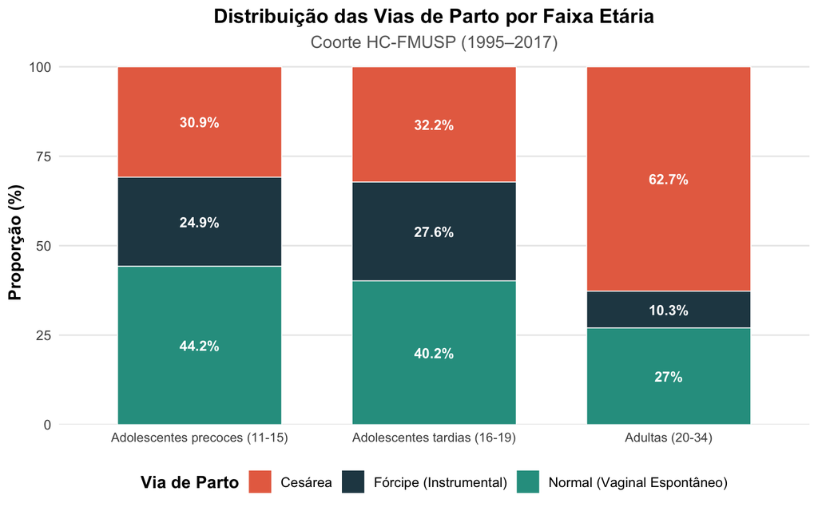

Figura 1: Distribuição proporcional das vias de parto por faixa etária

```r
fig1_data <- dados_analise %>%
    count(faixa_etaria_f, tipo_parto_desc) %>%
    group_by(faixa_etaria_f) %>%
    mutate(pct = n / sum(n) * 100) %>%
    ungroup()

p_fig1 <- ggplot(fig1_data, aes(x = faixa_etaria_f, y = pct, fill = tipo_parto_desc)) +
    geom_col(position = "stack", width = 0.7, color = "white", linewidth = 0.3) +
    geom_text(aes(label = paste0(round(pct, 1), "%")),
        position = position_stack(vjust = 0.5),
        size = 3.5, color = "white", fontface = "bold"
    ) +
    scale_fill_manual(values = cores_parto, name = "Via de Parto") +
    scale_y_continuous(expand = expansion(mult = c(0, 0.02))) +
    labs(
        title = "Distribuição das Vias de Parto por Faixa Etária",
        subtitle = "Coorte HC-FMUSP (1995–2017)",
        x = NULL, y = "Proporção (%)"
    ) +
    tema_pub +
    theme(axis.text.x = element_text(angle = 0, hjust = 0.5))

ggsave(here("results", "figures", "fig_obj2_vias_parto_geral.png"),
    plot = p_fig1, width = 8, height = 5, dpi = 300
)
p_fig1
```

## 3.2 Estratificação por Classificação de Robson

### 3.2.1 Tabela Cruzada: Robson × Faixa Etária × Via de Parto

**Mostrar código**

```r
tab_robson <- dados_analise %>%
    count(Robson_cat_f, faixa_etaria_f, tipo_parto_desc) %>%
    group_by(Robson_cat_f, faixa_etaria_f) %>%
    mutate(
        total = sum(n),
        pct = round(n / total * 100, 1),
        n_pct = paste0(n, " (", pct, "%)")
    ) %>%
    select(Robson_cat_f, faixa_etaria_f, tipo_parto_desc, n_pct) %>%
    pivot_wider(names_from = tipo_parto_desc, values_from = n_pct, values_fill = "0 (0%)") %>%
    ungroup()

tab_robson %>%
    rename(`Grupo Robson` = Robson_cat_f, `Faixa Etária` = faixa_etaria_f) %>%
    kable() %>%
    kable_styling(
        bootstrap_options = c("striped", "hover", "condensed"),
        full_width = TRUE, font_size = 12
    ) %>%
    collapse_rows(columns = 1, valign = "top")
```

Tabela 6: Vias de parto por Grupo de Robson e faixa etária — n (%)

| Grupo Robson | Faixa Etária | Cesárea | Fórcipe (Instrumental) | Normal (Vaginal Espontâneo) |
| --- | --- | --- | --- | --- |
| Grupo 1 | Adolescentes precoces (11-15) | 109 (27.7%) | 96 (24.4%) | 188 (47.8%) |
|  | Adolescentes tardias (16-19) | 138 (27.1%) | 169 (33.2%) | 202 (39.7%) |
|  | Adultas (20-34) | 147 (37.6%) | 132 (33.8%) | 112 (28.6%) |
| Grupo 2 | Adolescentes precoces (11-15) | 25 (47.2%) | 22 (41.5%) | 6 (11.3%) |
|  | Adolescentes tardias (16-19) | 47 (58%) | 22 (27.2%) | 12 (14.8%) |
|  | Adultas (20-34) | 674 (71.8%) | 157 (16.7%) | 108 (11.5%) |
| Grupo 3 | Adolescentes precoces (11-15) | 11 (42.3%) | 5 (19.2%) | 10 (38.5%) |
|  | Adolescentes tardias (16-19) | 26 (25.2%) | 20 (19.4%) | 57 (55.3%) |
|  | Adultas (20-34) | 153 (19.3%) | 95 (12%) | 544 (68.7%) |
| Grupo 4 | Adultas (20-34) | 206 (48.6%) | 39 (9.2%) | 179 (42.2%) |
| Grupo 5 | Adultas (20-34) | 1048 (89.2%) | 54 (4.6%) | 73 (6.2%) |
| Grupo 6 | Adolescentes precoces (11-15) | 1 (100%) | 0 (0%) | 0 (0%) |
|  | Adolescentes tardias (16-19) | 1 (100%) | 0 (0%) | 0 (0%) |
|  | Adultas (20-34) | 37 (94.9%) | 0 (0%) | 2 (5.1%) |
| Grupo 7 | Adolescentes precoces (11-15) | 4 (100%) | 0 (0%) | 0 (0%) |
|  | Adolescentes tardias (16-19) | 17 (94.4%) | 0 (0%) | 1 (5.6%) |
|  | Adultas (20-34) | 272 (90.7%) | 0 (0%) | 28 (9.3%) |
| Grupo 9 | Adolescentes precoces (11-15) | 5 (100%) | 0 (0%) | 0 (0%) |
|  | Adolescentes tardias (16-19) | 2 (100%) | 0 (0%) | 0 (0%) |
|  | Adultas (20-34) | 36 (90%) | 0 (0%) | 4 (10%) |
| Grupo 10 | Adolescentes precoces (11-15) | 11 (19.6%) | 11 (19.6%) | 34 (60.7%) |
|  | Adolescentes tardias (16-19) | 36 (31.3%) | 18 (15.7%) | 61 (53%) |
|  | Adultas (20-34) | 740 (62.6%) | 67 (5.7%) | 376 (31.8%) |

### 3.2.2 Figura: Vias de Parto Facetadas por Grupo de Robson

**Mostrar código**

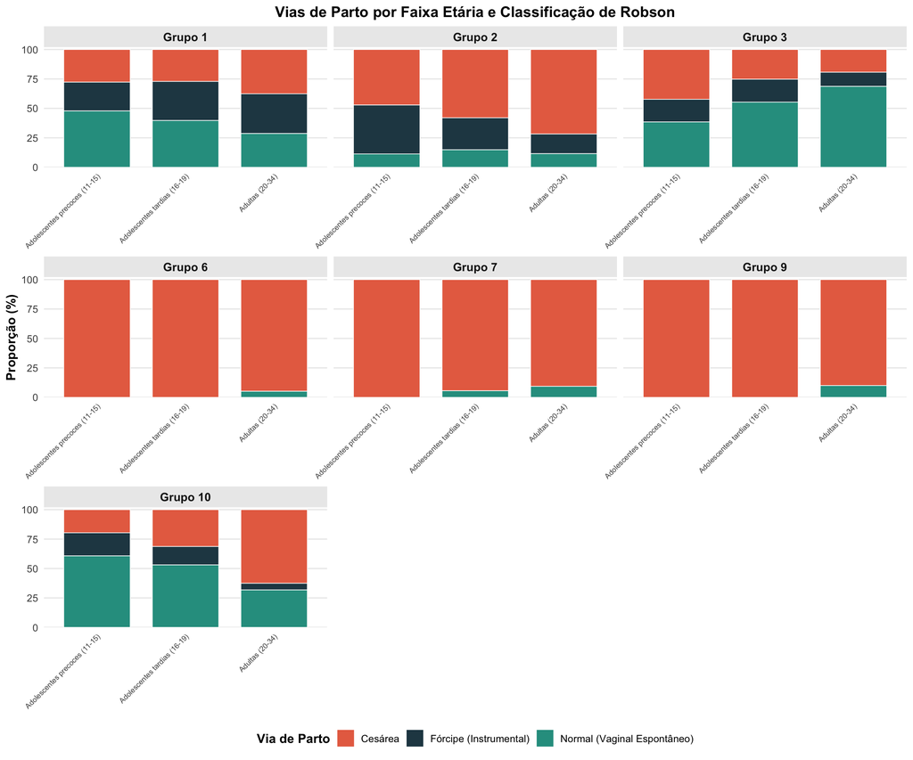

Figura 2: Proporção das vias de parto por faixa etária em cada Grupo de Robson (apenas grupos com ≥ 2 faixas etárias e n ≥ 20)

```r
# Filtrar grupos com dados suficientes
grupos_suficientes <- dados_analise %>%
    count(Robson_cat_f, faixa_etaria_f) %>%
    group_by(Robson_cat_f) %>%
    summarise(n_faixas = n_distinct(faixa_etaria_f), n_total = sum(n), .groups = "drop") %>%
    filter(n_faixas >= 2, n_total >= 20) %>%
    pull(Robson_cat_f)

fig2_data <- dados_analise %>%
    filter(Robson_cat_f %in% grupos_suficientes) %>%
    count(Robson_cat_f, faixa_etaria_f, tipo_parto_desc) %>%
    group_by(Robson_cat_f, faixa_etaria_f) %>%
    mutate(pct = n / sum(n) * 100) %>%
    ungroup()

p_fig2 <- ggplot(fig2_data, aes(x = faixa_etaria_f, y = pct, fill = tipo_parto_desc)) +
    geom_col(position = "stack", width = 0.75, color = "white", linewidth = 0.3) +
    facet_wrap(~Robson_cat_f, scales = "free_x", ncol = 3) +
    scale_fill_manual(values = cores_parto, name = "Via de Parto") +
    scale_y_continuous(expand = expansion(mult = c(0, 0.02))) +
    labs(
        title = "Vias de Parto por Faixa Etária e Classificação de Robson",
        x = NULL, y = "Proporção (%)"
    ) +
    tema_pub +
    theme(axis.text.x = element_text(angle = 45, hjust = 1, size = 7))

ggsave(here("results", "figures", "fig_obj2_robson_facetado.png"),
    plot = p_fig2, width = 12, height = 10, dpi = 300
)
p_fig2
```

## 3.3 Testes Estatísticos por Grupo de Robson

Para cada grupo de Robson, testamos a associação entre faixa etária e via de parto. Utilizamos o **teste qui-quadrado** quando todas as frequências esperadas são ≥ 5, e o **teste exato de Fisher** (com simulação de Monte Carlo, B = 10.000) quando alguma célula apresenta frequência esperada < 5.

**Mostrar código**

```r
robson_groups <- sort(unique(as.numeric(dados_analise$Robson_cat)))
resultados_testes <- list()

for (grp in robson_groups) {
    sub <- dados_analise %>% filter(as.numeric(Robson_cat) == grp)
    n_sub <- nrow(sub)
    faixas_presentes <- length(unique(sub$faixa_etaria_f))
    partos_presentes <- length(unique(sub$tipo_parto_desc))

    if (faixas_presentes < 2 || partos_presentes < 2 || n_sub < 10) {
        resultados_testes[[as.character(grp)]] <- data.frame(
            Robson = grp, n = n_sub, Teste = "Não aplicável",
            Estatística = NA, gl = NA, `p-valor` = NA,
            Significância = "—", check.names = FALSE
        )
        next
    }

    tab <- table(sub$tipo_parto_desc, sub$faixa_etaria_f)
    tab <- tab[rowSums(tab) > 0, colSums(tab) > 0, drop = FALSE]

    if (min(dim(tab)) < 2) {
        resultados_testes[[as.character(grp)]] <- data.frame(
            Robson = grp, n = n_sub, Teste = "Não aplicável",
            Estatística = NA, gl = NA, `p-valor` = NA,
            Significância = "—", check.names = FALSE
        )
        next
    }

    expected <- chisq.test(tab)$expected
    if (any(expected < 5)) {
        test_result <- fisher.test(tab, simulate.p.value = TRUE, B = 10000)
        test_name <- "Fisher (MC)"
        stat_val <- NA
        df_val <- NA
    } else {
        test_result <- chisq.test(tab)
        test_name <- "Qui-quadrado"
        stat_val <- round(test_result$statistic, 3)
        df_val <- test_result$parameter
    }

    p_val <- test_result$p.value
    sig <- ifelse(p_val < 0.001, "***",
        ifelse(p_val < 0.01, "**",
            ifelse(p_val < 0.05, "*", "ns")
        )
    )

    resultados_testes[[as.character(grp)]] <- data.frame(
        Robson = grp, n = n_sub, Teste = test_name,
        Estatística = stat_val, gl = df_val,
        `p-valor` = round(p_val, 4),
        Significância = sig, check.names = FALSE
    )
}

tab_testes <- bind_rows(resultados_testes)

tab_testes %>%
    mutate(Robson = paste("Grupo", Robson)) %>%
    kable(align = "lrlrrrl") %>%
    kable_styling(bootstrap_options = c("striped", "hover"), full_width = FALSE) %>%
    footnote(general = "*** p < 0,001; ** p < 0,01; * p < 0,05; ns = não significativo; MC = Monte Carlo (B=10.000)")
```

Tabela 7: Testes de associação entre via de parto e faixa etária — por Grupo de Robson

|  | Robson | n | Teste | Estatística | gl | p-valor | Significância |
| --- | --- | --- | --- | --- | --- | --- | --- |
| X-squared...1 | Grupo 1 | 1293 | Qui-quadrado | 35.386 | 4 | 0.0000 | *** |
| X-squared...2 | Grupo 2 | 1073 | Qui-quadrado | 26.522 | 4 | 0.0000 | *** |
| ...3 | Grupo 3 | 921 | Fisher (MC) | NA | NA | 0.0011 | ** |
| ...4 | Grupo 4 | 424 | Não aplicável | NA | NA | NA | — |
| ...5 | Grupo 5 | 1175 | Não aplicável | NA | NA | NA | — |
| ...6 | Grupo 6 | 41 | Fisher (MC) | NA | NA | 1.0000 | ns |
| ...7 | Grupo 7 | 322 | Fisher (MC) | NA | NA | 1.0000 | ns |
| ...8 | Grupo 9 | 47 | Fisher (MC) | NA | NA | 1.0000 | ns |
| ...9 | Grupo 10 | 1354 | Fisher (MC) | NA | NA | 0.0001 | *** |

Note:  
*** p < 0,001; ** p < 0,01; * p < 0,05; ns = não significativo; MC = Monte Carlo (B=10.000)

**ImportanteResultados dos Testes por Grupo**

## 3.4 Taxa de Cesárea por Grupo de Robson e Faixa Etária

**Mostrar código**

```r
tab_cesarea <- dados_analise %>%
    mutate(cesarea = ifelse(tipo_parto == 2, 1, 0)) %>%
    group_by(Robson_cat_f, faixa_etaria_f) %>%
    summarise(
        N = n(),
        `Cesáreas` = sum(cesarea),
        `Taxa (%)` = round(sum(cesarea) / n() * 100, 1),
        .groups = "drop"
    )

tab_cesarea %>%
    rename(`Grupo Robson` = Robson_cat_f, `Faixa Etária` = faixa_etaria_f) %>%
    kable() %>%
    kable_styling(bootstrap_options = c("striped", "hover"), full_width = FALSE) %>%
    collapse_rows(columns = 1, valign = "top")
```

Tabela 8: Taxa de cesárea por Grupo de Robson e faixa etária

| Grupo Robson | Faixa Etária | N | Cesáreas | Taxa (%) |
| --- | --- | --- | --- | --- |
| Grupo 1 | Adolescentes precoces (11-15) | 393 | 109 | 27.7 |
|  | Adolescentes tardias (16-19) | 509 | 138 | 27.1 |
|  | Adultas (20-34) | 391 | 147 | 37.6 |
| Grupo 2 | Adolescentes precoces (11-15) | 53 | 25 | 47.2 |
|  | Adolescentes tardias (16-19) | 81 | 47 | 58.0 |
|  | Adultas (20-34) | 939 | 674 | 71.8 |
| Grupo 3 | Adolescentes precoces (11-15) | 26 | 11 | 42.3 |
|  | Adolescentes tardias (16-19) | 103 | 26 | 25.2 |
|  | Adultas (20-34) | 792 | 153 | 19.3 |
| Grupo 4 | Adultas (20-34) | 424 | 206 | 48.6 |
| Grupo 5 | Adultas (20-34) | 1175 | 1048 | 89.2 |
| Grupo 6 | Adolescentes precoces (11-15) | 1 | 1 | 100.0 |
|  | Adolescentes tardias (16-19) | 1 | 1 | 100.0 |
|  | Adultas (20-34) | 39 | 37 | 94.9 |
| Grupo 7 | Adolescentes precoces (11-15) | 4 | 4 | 100.0 |
|  | Adolescentes tardias (16-19) | 18 | 17 | 94.4 |
|  | Adultas (20-34) | 300 | 272 | 90.7 |
| Grupo 9 | Adolescentes precoces (11-15) | 5 | 5 | 100.0 |
|  | Adolescentes tardias (16-19) | 2 | 2 | 100.0 |
|  | Adultas (20-34) | 40 | 36 | 90.0 |
| Grupo 10 | Adolescentes precoces (11-15) | 56 | 11 | 19.6 |
|  | Adolescentes tardias (16-19) | 115 | 36 | 31.3 |
|  | Adultas (20-34) | 1183 | 740 | 62.6 |

### 3.4.1 Figura: Mapa de Calor da Taxa de Cesárea

**Mostrar código**

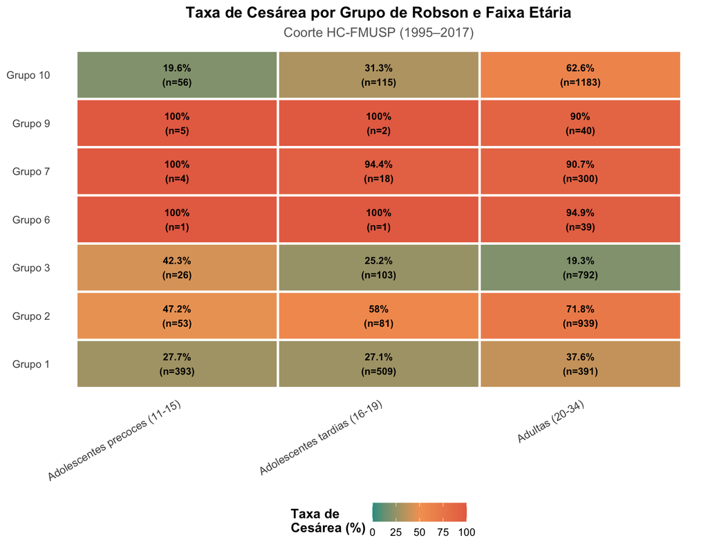

Figura 3: Mapa de calor da taxa de cesárea (%) por Grupo de Robson e faixa etária. Células verdes indicam taxas mais baixas; alaranjadas/vermelhas indicam taxas mais altas.

```r
fig3_data <- tab_cesarea %>%
    filter(Robson_cat_f %in% grupos_suficientes)

p_fig3 <- ggplot(fig3_data, aes(x = faixa_etaria_f, y = Robson_cat_f, fill = `Taxa (%)`)) +
    geom_tile(color = "white", linewidth = 1) +
    geom_text(aes(label = paste0(`Taxa (%)`, "%\n(n=", N, ")")),
        size = 3.2, fontface = "bold"
    ) +
    scale_fill_gradient2(
        low = "#2a9d8f", mid = "#f4a261", high = "#e76f51",
        midpoint = 50, name = "Taxa de\nCesárea (%)",
        limits = c(0, 100)
    ) +
    labs(
        title = "Taxa de Cesárea por Grupo de Robson e Faixa Etária",
        subtitle = "Coorte HC-FMUSP (1995–2017)",
        x = NULL, y = NULL
    ) +
    tema_pub +
    theme(
        axis.text.x = element_text(angle = 30, hjust = 1, size = 10),
        panel.grid = element_blank()
    )

ggsave(here("results", "figures", "fig_obj2_heatmap_cesarea.png"),
    plot = p_fig3, width = 9, height = 7, dpi = 300
)
p_fig3
```

### 3.4.2 Figura: Adolescentes vs. Adultas (Comparação Direta)

**Mostrar código**

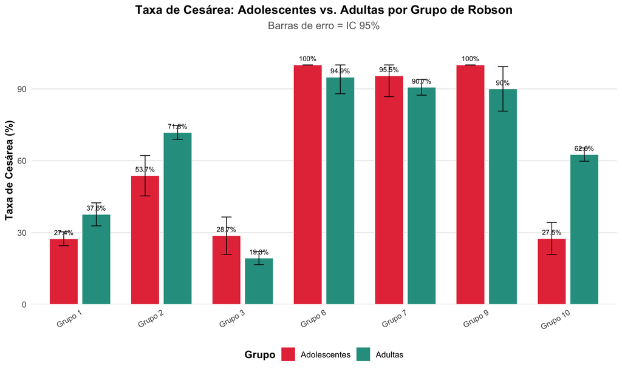

Figura 4: Comparação da taxa de cesárea entre adolescentes e adultas por Grupo de Robson (com intervalos de confiança de 95%)

```r
fig4_data <- dados_analise %>%
    mutate(cesarea = ifelse(tipo_parto == 2, 1, 0)) %>%
    group_by(Robson_cat_f, grupo_comparativo) %>%
    summarise(
        n = n(),
        taxa = mean(cesarea) * 100,
        se = sqrt(taxa / 100 * (1 - taxa / 100) / n) * 100,
        .groups = "drop"
    ) %>%
    filter(Robson_cat_f %in% grupos_suficientes)

p_fig4 <- ggplot(fig4_data, aes(x = Robson_cat_f, y = taxa, fill = grupo_comparativo)) +
    geom_col(
        position = position_dodge(width = 0.8), width = 0.7,
        color = "white", linewidth = 0.3
    ) +
    geom_errorbar(
        aes(
            ymin = pmax(taxa - 1.96 * se, 0),
            ymax = pmin(taxa + 1.96 * se, 100)
        ),
        position = position_dodge(width = 0.8),
        width = 0.25, linewidth = 0.4
    ) +
    geom_text(aes(label = paste0(round(taxa, 1), "%")),
        position = position_dodge(width = 0.8), vjust = -0.8, size = 2.8
    ) +
    scale_fill_manual(
        values = c("Adolescentes" = "#e63946", "Adultas" = "#2a9d8f"),
        name = "Grupo"
    ) +
    scale_y_continuous(expand = expansion(mult = c(0, 0.12)), limits = c(0, NA)) +
    labs(
        title = "Taxa de Cesárea: Adolescentes vs. Adultas por Grupo de Robson",
        subtitle = "Barras de erro = IC 95%",
        x = NULL, y = "Taxa de Cesárea (%)"
    ) +
    tema_pub

ggsave(here("results", "figures", "fig_obj2_cesarea_adol_vs_adultas.png"),
    plot = p_fig4, width = 10, height = 6, dpi = 300
)
p_fig4
```

## 3.5 Interpretação dos Resultados — Objetivo 2

**NotaSíntese dos Achados — Objetivo 2**

**Achados gerais:**

- A taxa global de cesárea é menor entre adolescentes (31.7%) do que entre adultas (62.7%).
- Em contrapartida, as adolescentes apresentam taxas mais elevadas de **parto por fórcipe**.
- A associação entre faixa etária e via de parto é **estatisticamente significativa** (χ² de Pearson, p < 0,001).

**Por Grupo de Robson:**

# 4 Objetivo 3: Mapeamento de Indicações Operatórias

Análise das **5 principais indicações clínicas** para cesárea e fórcipe, comparando adolescentes e adultas.

**Mostrar código**

```r
dados_operatorio <- dados_analise %>%
    filter(tipo_parto %in% c(2, 3)) %>%
    mutate(indicacao_desc = ifelse(
        is.na(indicacao_cat) | indicacao_cat == "",
        "Não informada", indicacao_cat
    ))

indicacoes_summary <- dados_operatorio %>%
    group_by(tipo_parto_desc, grupo_comparativo, indicacao_desc) %>%
    tally() %>%
    arrange(tipo_parto_desc, grupo_comparativo, desc(n)) %>%
    group_by(tipo_parto_desc, grupo_comparativo) %>%
    slice_max(order_by = n, n = 5) %>%
    mutate(
        `%` = round((n / sum(n)) * 100, 1),
        n_pct = paste0(n, " (", `%`, "%)")
    ) %>%
    ungroup()

indicacoes_summary %>%
    select(
        `Via de Parto` = tipo_parto_desc,
        Grupo = grupo_comparativo,
        Indicação = indicacao_desc,
        `n (%)` = n_pct
    ) %>%
    kable() %>%
    kable_styling(
        bootstrap_options = c("striped", "hover", "condensed"),
        full_width = FALSE
    ) %>%
    collapse_rows(columns = 1:2, valign = "top")
```

Tabela 9: Top 5 indicações clínicas para partos operatórios (cesárea e fórcipe) por grupo etário

| Via de Parto | Grupo | Indicação | n (%) |
| --- | --- | --- | --- |
| Cesárea | Adolescentes | Não informada | 264 (68.4%) |
|  |  | Distocia funcional | 37 (9.6%) |
|  |  | Mecônio | 35 (9.1%) |
|  |  | Sofrimento fetal | 28 (7.3%) |
|  |  | Desproporção céfalo-pélvica | 22 (5.7%) |
|  | Adultas | Sofrimento fetal | 552 (27.6%) |
|  |  | Não informada | 514 (25.7%) |
|  |  | Patologia materna | 381 (19.1%) |
|  |  | Distocia funcional | 288 (14.4%) |
|  |  | Iteratividade | 263 (13.2%) |
| Fórcipe (Instrumental) | Adolescentes | Não informada | 216 (60.2%) |
|  |  | Alívio materno-fetal | 62 (17.3%) |
|  |  | Abreviação do período expulsivo | 41 (11.4%) |
|  |  | Distocia de rotação | 36 (10%) |
|  |  | Mecônio | 4 (1.1%) |
|  | Adultas | Alívio materno-fetal | 208 (39.5%) |
|  |  | Abreviação do período expulsivo | 177 (33.6%) |
|  |  | Distocia de rotação | 95 (18%) |
|  |  | Não informada | 37 (7%) |
|  |  | Sofrimento fetal | 10 (1.9%) |

### 4.0.1 Figura: Indicações para Cesárea

**Mostrar código**

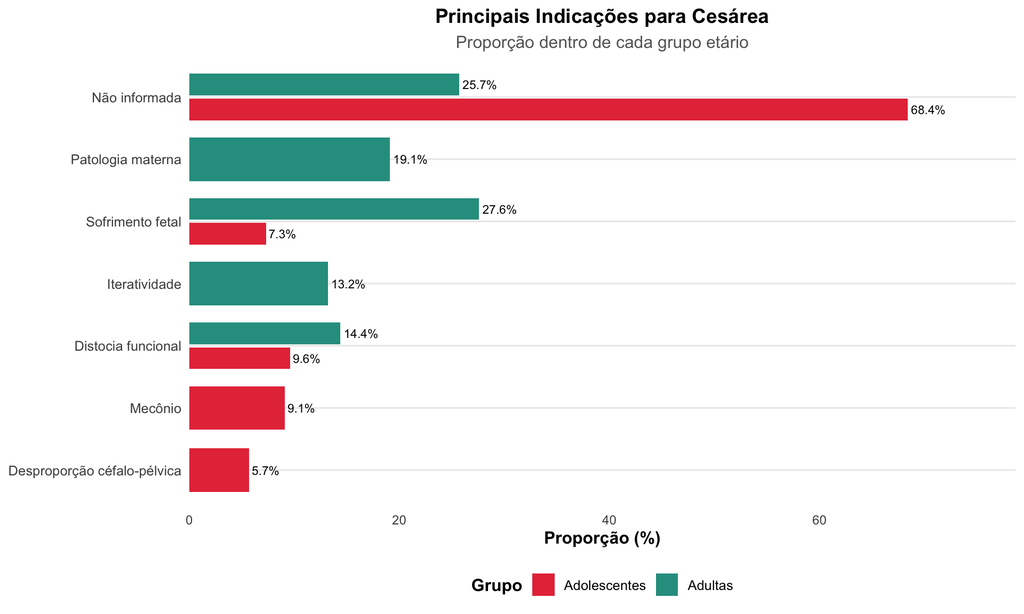

Figura 5: Top 5 indicações clínicas para cesárea — Adolescentes vs. Adultas

```r
# Reprodução standalone: analysis/03_indicacoes_parto.R
ind_ces <- indicacoes_summary %>%
    filter(tipo_parto_desc == "Cesárea")

# Salvar tabela de indicações de cesárea
write.csv(
    ind_ces %>% select(
        `Via de Parto` = tipo_parto_desc, Grupo = grupo_comparativo,
        Indicação = indicacao_desc, n, `%`
    ),
    here("results", "tabelas_dissertacao", "tab08_indicacoes_cesarea.csv"),
    row.names = FALSE, fileEncoding = "UTF-8"
)

p_fig5 <- ggplot(ind_ces, aes(x = reorder(indicacao_desc, n), y = `%`, fill = grupo_comparativo)) +
    geom_col(position = position_dodge(width = 0.8), width = 0.7) +
    geom_text(aes(label = paste0(`%`, "%")),
        position = position_dodge(width = 0.8), hjust = -0.1, size = 3
    ) +
    coord_flip() +
    scale_fill_manual(
        values = c("Adolescentes" = "#e63946", "Adultas" = "#2a9d8f"),
        name = "Grupo"
    ) +
    scale_y_continuous(expand = expansion(mult = c(0, 0.15))) +
    labs(
        title = "Principais Indicações para Cesárea",
        subtitle = "Proporção dentro de cada grupo etário",
        x = NULL, y = "Proporção (%)"
    ) +
    tema_pub +
    theme(axis.text.x = element_text(angle = 0, hjust = 0.5))

ggsave(here("results", "figures", "fig_obj3_indicacoes_cesarea.png"),
    plot = p_fig5, width = 10, height = 6, dpi = 300
)
p_fig5
```

### 4.0.2 Figura: Indicações para Fórcipe

**Mostrar código**

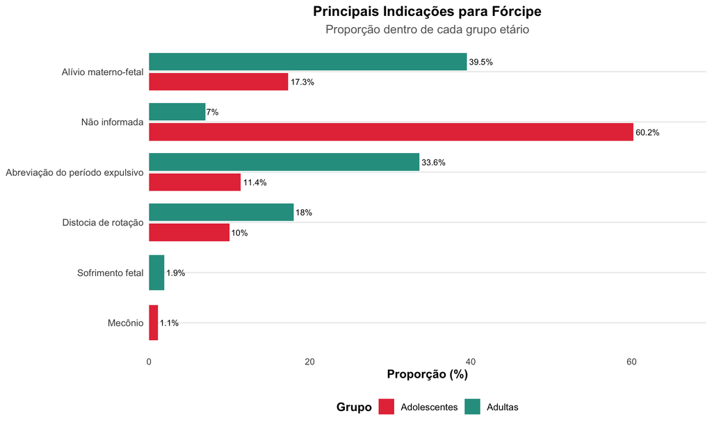

Figura 6: Top 5 indicações clínicas para fórcipe — Adolescentes vs. Adultas

```r
# Reprodução standalone: analysis/03_indicacoes_parto.R
ind_forc <- indicacoes_summary %>%
    filter(tipo_parto_desc == "Fórcipe (Instrumental)")

# Salvar tabela de indicações de fórcipe
write.csv(
    ind_forc %>% select(
        `Via de Parto` = tipo_parto_desc, Grupo = grupo_comparativo,
        Indicação = indicacao_desc, n, `%`
    ),
    here("results", "tabelas_dissertacao", "tab09_indicacoes_forcipe.csv"),
    row.names = FALSE, fileEncoding = "UTF-8"
)

p_fig6 <- ggplot(ind_forc, aes(x = reorder(indicacao_desc, n), y = `%`, fill = grupo_comparativo)) +
    geom_col(position = position_dodge(width = 0.8), width = 0.7) +
    geom_text(aes(label = paste0(`%`, "%")),
        position = position_dodge(width = 0.8), hjust = -0.1, size = 3
    ) +
    coord_flip() +
    scale_fill_manual(
        values = c("Adolescentes" = "#e63946", "Adultas" = "#2a9d8f"),
        name = "Grupo"
    ) +
    scale_y_continuous(expand = expansion(mult = c(0, 0.15))) +
    labs(
        title = "Principais Indicações para Fórcipe",
        subtitle = "Proporção dentro de cada grupo etário",
        x = NULL, y = "Proporção (%)"
    ) +
    tema_pub +
    theme(axis.text.x = element_text(angle = 0, hjust = 0.5))

ggsave(here("results", "figures", "fig_obj3_indicacoes_forcipe.png"),
    plot = p_fig6, width = 10, height = 6, dpi = 300
)
p_fig6
```

# 5 Objetivo 4: Complicações Maternas

**Mostrar código**

```r
if ("compli_parto" %in% colnames(dados_analise)) {
    tab_compli <- dados_analise %>%
        filter(!is.na(compli_parto)) %>%
        count(grupo_comparativo, compli_parto) %>%
        group_by(grupo_comparativo) %>%
        mutate(
            pct = round(n / sum(n) * 100, 1),
            n_pct = paste0(n, " (", pct, "%)")
        ) %>%
        select(grupo_comparativo, compli_parto, n_pct) %>%
        pivot_wider(names_from = grupo_comparativo, values_from = n_pct, values_fill = "0 (0%)")

    tab_compli %>%
        rename(Complicação = compli_parto) %>%
        kable() %>%
        kable_styling(bootstrap_options = c("striped", "hover"), full_width = FALSE)
} else {
    cat("Variável 'compli_parto' não encontrada na base de dados.\n")
}
```

Tabela 10: Complicações no parto por grupo etário — n (%)

| Complicação | Adolescentes | Adultas |
| --- | --- | --- |
| Cefaleia Pos-Raqui | 1 (0.2%) | 0 (0%) |
| Deiscência | 14 (2.5%) | 0 (0%) |
| Febre a esclarecer | 6 (1.1%) | 1 (0%) |
| Fissura mamária | 3 (0.5%) | 0 (0%) |
| Hematoma | 1 (0.2%) | 0 (0%) |
| Hemorragia | 1 (0.2%) | 0 (0%) |
| Hipotonia | 1 (0.2%) | 0 (0%) |
| Infecção | 11 (1.9%) | 0 (0%) |
| Laceração | 3 (0.5%) | 0 (0%) |
| Mastite | 4 (0.7%) | 0 (0%) |
| Outros | 5 (0.9%) | 0 (0%) |
| Retenção Placentária | 2 (0.4%) | 0 (0%) |
| Sangramento | 5 (0.9%) | 0 (0%) |
| Sem complicações | 514 (90%) | 4743 (95.7%) |
| Acretismo placentário | 0 (0%) | 21 (0.4%) |
| Atonia uterina | 0 (0%) | 38 (0.8%) |
| Histerectomia | 0 (0%) | 9 (0.2%) |
| Lacerações do canal de Parto | 0 (0%) | 135 (2.7%) |
| Lacerações do ânus e reto | 0 (0%) | 4 (0.1%) |
| Lesão vesical | 0 (0%) | 1 (0%) |
| Ligaduras das artérias hipogástricas | 0 (0%) | 2 (0%) |

# 6 Análises Complementares — Resultados do SPSS

**ImportanteProveniência das análises desta seção**

O diagrama abaixo ilustra o mapeamento das abordagens metodológicas adotadas nas modelagens (modelos clínicos diretos e ajustados pela classificação de Robson):

[output not shown]

## 6.1 Leitura do arquivo de resultados SPSS

**Mostrar código**

```r
# Leitura do arquivo .ods com os resultados do SPSS
# Requer o pacote readODS (>= 2.0) ou openxlsx2 com suporte a odf.
# Alternativa robusta: utilizar o pacote readODS via CRAN.
if (!requireNamespace("readODS", quietly = TRUE)) {
    # Se readODS não estiver disponível, informar ao usuário
    cat("AVISO: pacote 'readODS' não encontrado. Instale com: install.packages('readODS')\n")
    cat("As tabelas SPSS abaixo serão exibidas a partir de dados embutidos no código.\n")
    ods_disponivel <- FALSE
} else {
    library(readODS)
    ods_path <- here("analysis", "Resultados_finais.ods")
    tryCatch(
        {
            ods_descricao <- read_ods(ods_path, sheet = "descrição geral da base de dados")
            ods_modelos <- read_ods(ods_path, sheet = "modelos sugeridos cesarea")
            ods_disponivel <- TRUE
            cat("Arquivo Resultados_finais.ods lido com sucesso.\n")
            cat("Aba 'descrição geral': ", nrow(ods_descricao), "linhas ×", ncol(ods_descricao), "colunas\n")
            cat("Aba 'modelos sugeridos': ", nrow(ods_modelos), "linhas ×", ncol(ods_modelos), "colunas\n")
        },
        error = function(e) {
            cat("Erro ao ler o .ods:", conditionMessage(e), "\n")
            ods_disponivel <<- FALSE
        }
    )
}
```

```
AVISO: pacote 'readODS' não encontrado. Instale com: install.packages('readODS')
As tabelas SPSS abaixo serão exibidas a partir de dados embutidos no código.
```

## 6.2 Descrição Geral da Base de Dados (SPSS)

Esta seção reproduz os principais cruzamentos da aba *“descrição geral da base de dados”* do SPSS. As análises foram conduzidas pela estatística do programa de pós-graduação no SPSS e estão sendo apresentadas aqui para fins de rastreabilidade e reprodutibilidade.

Os cruzamentos foram realizados entre as características maternas/neonatais e a faixa etária materna em 3 categorias elegíveis: **11–15 anos**, **16–19 anos** e **20–34 anos**. Gestantes com 35 anos ou mais foram desconsideradas para alinhamento com os critérios de elegibilidade do manuscrito. Utilizou-se o **teste Qui-quadrado de Pearson** para todos os cruzamentos.

**Mostrar código**

```r
# Tabela construída a partir dos valores do SPSS (Relatorio Analise SPSS.md)
# Fonte: aba 'descrição geral da base de dados', variável tipo_parto * grupo
tab_vias_spss <- data.frame(
    `Faixa Etária` = c("11 a 15 anos", "16 a 19 anos", "20 a 34 anos"),
    `Normal (%)` = c("45,4%", "41,2%", "27,5%"),
    `Fórcipe (%)` = c("24,5%", "27,3%", "10,2%"),
    `Cesárea (%)` = c("30,1%", "31,4%", "62,3%"),
    check.names = FALSE
)

tab_vias_spss %>%
    kable(
        align = "lrrr",
        caption = "Distribuição das vias de parto por faixa etária (SPSS). p < 0,001 (Qui-quadrado de Pearson)."
    ) %>%
    kable_styling(bootstrap_options = c("striped", "hover"), full_width = FALSE) %>%
    row_spec(0, bold = TRUE, background = "#e9ecef") %>%
    footnote(general = "Análise conduzida no SPSS pela estatística do programa. N total = 8.300 (após exclusão de registros sem tipo_parto ou idade). Fonte: Resultados_finais.ods, aba 'descrição geral da base de dados'.")
write.csv(tab_vias_spss,
    here("results", "tabelas_dissertacao", "tab04_vias_parto_spss.csv"),
    row.names = FALSE, fileEncoding = "UTF-8"
)
```

Tabela 11: Distribuição das vias de parto por faixa etária — Análise SPSS (Tabela 4 dissertação)

Distribuição das vias de parto por faixa etária (SPSS). p < 0,001 (Qui-quadrado de Pearson).

| Faixa Etária | Normal (%) | Fórcipe (%) | Cesárea (%) |
| --- | --- | --- | --- |
| 11 a 15 anos | 45,4% | 24,5% | 30,1% |
| 16 a 19 anos | 41,2% | 27,3% | 31,4% |
| 20 a 34 anos | 27,5% | 10,2% | 62,3% |

**Mostrar código**

```r
# Construído a partir do Relatorio Analise SPSS.md
tab_habitos_spss <- data.frame(
    `Variável` = c("Álcool (uso declarado)", "Fumo (uso declarado)", "Drogas (uso declarado)"),
    `11–15 anos` = c("5,3%", "7,6%", "7,6%"),
    `16–19 anos` = c("5,4%", "13,2%", "11,8%"),
    `20–34 anos` = c("< referência", "< referência", "< referência"),
    `p-valor` = c("< 0,001", "< 0,001", "< 0,001"),
    check.names = FALSE
)

tab_habitos_spss %>%
    kable(align = "lrrrr") %>%
    kable_styling(bootstrap_options = c("striped", "hover"), full_width = FALSE) %>%
    row_spec(0, bold = TRUE, background = "#e9ecef") %>%
    footnote(general = "Análise conduzida no SPSS. O uso declarado de substâncias foi maior nas adolescentes do que nas adultas em todas as variáveis (p < 0,001). Fonte: Resultados_finais.ods.")
write.csv(tab_habitos_spss,
    here("results", "tabelas_dissertacao", "tab02_habitos_spss.csv"),
    row.names = FALSE, fileEncoding = "UTF-8"
)
```

Tabela 12: Hábitos de risco por faixa etária — Análise SPSS (Tabela 2 dissertação)

| Variável | 11–15 anos | 16–19 anos | 20–34 anos | p-valor |
| --- | --- | --- | --- | --- |
| Álcool (uso declarado) | 5,3% | 5,4% | < referência | < 0,001 |
| Fumo (uso declarado) | 7,6% | 13,2% | < referência | < 0,001 |
| Drogas (uso declarado) | 7,6% | 11,8% | < referência | < 0,001 |

Note:  
Análise conduzida no SPSS. O uso declarado de substâncias foi maior nas adolescentes do que nas adultas em todas as variáveis (p < 0,001). Fonte: Resultados_finais.ods.

**Mostrar código**

```r
tab_comorbidades_spss <- data.frame(
    `Variável` = c(
        "Patologia materna (geral)",
        "Hipertensão Arterial Crônica (hac_pre)",
        "Diabetes Pré-gestacional (diabetes_pre)",
        "Diabetes Gestacional (dmg_obst)",
        "Distúrbios Hipertensivos Gestação (dheg_hipertensao_obst)",
        "Pré-eclâmpsia (pe_obst)",
        "Eclâmpsia (eclampsia_obst)",
        "Ruptura Prematura de Membranas (rpmo)"
    ),
    `11–15 anos` = c("3,4%", "0,4%", "0,0%", "0,5%", "100,0%", "100,0%", "—", "0,2%"),
    `16–19 anos` = c("—", "—", "—", "—", "96,7%", "94,6%", "33,3%", "0,0%"),
    `20–34 anos` = c("28,7%", "7,4%", "3,3%", "10,6%", "—", "—", "1,8%", "8,6%"),
    `p-valor` = c("< 0,001", "< 0,001", "< 0,001", "< 0,001", "< 0,001", "< 0,001", "< 0,001", "< 0,001"),
    check.names = FALSE
)

tab_comorbidades_spss %>%
    kable(align = "lrrrr") %>%
    kable_styling(bootstrap_options = c("striped", "hover"), full_width = FALSE) %>%
    row_spec(0, bold = TRUE, background = "#e9ecef") %>%
    footnote(
        general = "— = dado não destacado no relatório SPSS para essa célula específica. Análise conduzida no SPSS pela estatística do programa. Fonte: Resultados_finais.ods.",
        symbol = "Os percentuais de dheg/pe em adolescentes referem-se às pacientes que tiveram o registro da variável obstétrica preenchido, não à prevalência no grupo total."
    )
write.csv(tab_comorbidades_spss,
    here("results", "tabelas_dissertacao", "tab03_comorbidades_spss.csv"),
    row.names = FALSE, fileEncoding = "UTF-8"
)
```

Tabela 13: Comorbidades pré-gestacionais e patologias da gestação por faixa etária — Análise SPSS (Tabela 3 dissertação)

| Variável | 11–15 anos | 16–19 anos | 20–34 anos | p-valor |
| --- | --- | --- | --- | --- |
| Patologia materna (geral) | 3,4% | — | 28,7% | < 0,001 |
| Hipertensão Arterial Crônica (hac_pre) | 0,4% | — | 7,4% | < 0,001 |
| Diabetes Pré-gestacional (diabetes_pre) | 0,0% | — | 3,3% | < 0,001 |
| Diabetes Gestacional (dmg_obst) | 0,5% | — | 10,6% | < 0,001 |
| Distúrbios Hipertensivos Gestação (dheg_hipertensao_obst) | 100,0% | 96,7% | — | < 0,001 |
| Pré-eclâmpsia (pe_obst) | 100,0% | 94,6% | — | < 0,001 |
| Eclâmpsia (eclampsia_obst) | — | 33,3% | 1,8% | < 0,001 |
| Ruptura Prematura de Membranas (rpmo) | 0,2% | 0,0% | 8,6% | < 0,001 |

Note:  
— = dado não destacado no relatório SPSS para essa célula específica. Análise conduzida no SPSS pela estatística do programa. Fonte: Resultados_finais.ods.  
* Os percentuais de dheg/pe em adolescentes referem-se às pacientes que tiveram o registro da variável obstétrica preenchido, não à prevalência no grupo total.

**Mostrar código**

```r
tab_neonatal_spss <- data.frame(
    `Desfecho` = c(
        "Prematuridade < 37 sem (prematuro37)",
        "Baixo peso < 2500 g (rnbp_2500g)",
        "Apgar < 7 no 1º minuto",
        "Apgar < 7 no 5º minuto",
        "Óbito fetal (obito_fetal)",
        "Malformação fetal (malform_fetal)"
    ),
    `11–15 anos` = c("10,4%", "11,0%", "> adultas*", "> adultas*", "1,3%", "1,8%"),
    `16–19 anos` = c("14,4%", "12,8%", "> adultas*", "> adultas*", "—", "2,0%"),
    `20–34 anos` = c("24,4%", "21,9%", "ref.", "ref.", "2,5%", "6,9%"),
    `p-valor` = c("< 0,001", "< 0,001", "< 0,05", "< 0,05", "0,011", "< 0,001"),
    check.names = FALSE
)

tab_neonatal_spss %>%
    kable(align = "lrrrr") %>%
    kable_styling(bootstrap_options = c("striped", "hover"), full_width = FALSE) %>%
    row_spec(0, bold = TRUE, background = "#e9ecef") %>%
    footnote(
        general = "Análise conduzida no SPSS. Fonte: Resultados_finais.ods, aba 'descrição geral da base de dados'.",
        symbol = "* Taxas de Apgar baixo são discretamente maiores nas adultas; o relatório SPSS não apresentou percentuais exatos por faixa — apenas a direção da diferença e o p-valor."
    )
write.csv(tab_neonatal_spss,
    here("results", "tabelas_dissertacao", "tab11_desfechos_neonatais_spss.csv"),
    row.names = FALSE, fileEncoding = "UTF-8"
)
```

Tabela 14: Desfechos neonatais por faixa etária — Análise SPSS (Tabela 11 dissertação)

| Desfecho | 11–15 anos | 16–19 anos | 20–34 anos | p-valor |
| --- | --- | --- | --- | --- |
| Prematuridade < 37 sem (prematuro37) | 10,4% | 14,4% | 24,4% | < 0,001 |
| Baixo peso < 2500 g (rnbp_2500g) | 11,0% | 12,8% | 21,9% | < 0,001 |
| Apgar < 7 no 1º minuto | > adultas* | > adultas* | ref. | < 0,05 |
| Apgar < 7 no 5º minuto | > adultas* | > adultas* | ref. | < 0,05 |
| Óbito fetal (obito_fetal) | 1,3% | — | 2,5% | 0,011 |
| Malformação fetal (malform_fetal) | 1,8% | 2,0% | 6,9% | < 0,001 |

## 6.3 Modelos de Regressão Logística para Cesárea (SPSS)

Esta seção reproduz os resultados dos 4 modelos de regressão logística testados pela estatística do programa de pós-graduação no SPSS e está sendo apresentada aqui para fins de rastreabilidade e reprodutibilidade.

Foram testados **4 modelos** para estimar os fatores preditores independentes da ocorrência de parto cesárea. O critério de ajuste utilizado foi o **teste de Hosmer-Lemeshow** (um p-valor alto indica bom ajuste, pois não há diferença significativa entre valores observados e previstos).

**Mostrar código**

```r
tab_modelos_resumo <- data.frame(
    Modelo = c("Sugestão 1", "Sugestão 2", "Sugestão 3", "Sugestão 4 ★"),
    Variáveis = c(
        "Faixa etária + DHEG + Apresentação fetal",
        "Faixa etária + DHEG + Apresentação fetal + DMG",
        "Faixa etária + DHEG + Apresentação fetal + Robson*",
        "Faixa etária + DHEG + Robson (sem apresentação)"
    ),
    `HL χ²` = c("0,314", "1,547", "—", "5,215"),
    `HL p-valor` = c("0,855", "0,672", "—", "0,517"),
    `OR Idade Adulta` = c("2,54 (p=0,001)", "1,19 (p=0,904)", "1,55 (p=0,167)", "1,79 (p=0,015)"),
    Nota = c("Bom ajuste", "Bom ajuste", "Multicolinearidade (Robson + apres. fetal)", "MODELO ADOTADO"),
    check.names = FALSE
)

tab_modelos_resumo %>%
    kable(align = "llrrrll") %>%
    kable_styling(bootstrap_options = c("striped", "hover"), full_width = TRUE) %>%
    row_spec(0, bold = TRUE, background = "#e9ecef") %>%
    row_spec(4, bold = TRUE, background = "#d4edda") %>%
    footnote(
        general = "★ Modelo adotado como definitivo. HL = Hosmer-Lemeshow. * Sugestão 3 tem redundância: apresentação fetal é critério de classificação do Robson. Análise conduzida no SPSS.",
        general_title = "Nota:"
    )
```

Tabela 15: Resumo comparativo dos 4 modelos de regressão logística — Análise SPSS

| Modelo | Variáveis | HL χ² | HL p-valor | OR Idade Adulta | Nota |
| --- | --- | --- | --- | --- | --- |
| Sugestão 1 | Faixa etária + DHEG + Apresentação fetal | 0,314 | 0,855 | 2,54 (p=0,001) | Bom ajuste |
| Sugestão 2 | Faixa etária + DHEG + Apresentação fetal + DMG | 1,547 | 0,672 | 1,19 (p=0,904) | Bom ajuste |
| Sugestão 3 | Faixa etária + DHEG + Apresentação fetal + Robson* | — | — | 1,55 (p=0,167) | Multicolinearidade (Robson + apres. fetal) |
| Sugestão 4 ★ | Faixa etária + DHEG + Robson (sem apresentação) | 5,215 | 0,517 | 1,79 (p=0,015) | MODELO ADOTADO |

Nota:  
★ Modelo adotado como definitivo. HL = Hosmer-Lemeshow. * Sugestão 3 tem redundância: apresentação fetal é critério de classificação do Robson. Análise conduzida no SPSS.

**Mostrar código**

```r
# Modelo 4: dados extraídos diretamente da aba 'modelos sugeridos cesarea' do SPSS
# Hosmer-Lemeshow: χ² = 5,215; df = 6; p = 0,517
# Grupo de referência para Robson: Grupo 1 (nulípara espontânea ≥ 37 sem)
tab_modelo4 <- data.frame(
    Variável = c(
        "Faixa Etária Adulta (vs. Adolescente)",
        "Hipertensão Obstétrica / DHEG (Sim)",
        "Grupo de Robson 2 (Nulípara, induzida/CS pré-parto)",
        "Grupo de Robson 3 (Multípara, espontânea)",
        "Grupo de Robson 4 (Multípara, induzida/CS pré-parto)",
        "Grupo de Robson 5 (Multípara com cesárea prévia)",
        "Grupo de Robson 6 (Nulípara pélvica)",
        "Grupo de Robson 7 (Multípara pélvica)",
        "Grupo de Robson 9 (Apresentação anômala/transversa)",
        "Grupo de Robson 10 (Pré-termo)",
        "Constante"
    ),
    B = c(0.581, -0.914, 1.478, -0.727, 0.620, 2.613, 3.163, 3.130, 3.320, 0.988, -0.384),
    `p-valor` = c(
        "0,015", "< 0,001", "< 0,001", "< 0,001", "< 0,001", "< 0,001",
        "< 0,001", "< 0,001", "< 0,001", "< 0,001", "0,073"
    ),
    OR = c(1.79, 0.40, 4.38, 0.48, 1.86, 13.65, 23.65, 22.86, 27.66, 2.69, 0.68),
    `IC 95% inf` = c(1.12, 0.32, 3.30, 0.35, 1.33, 9.88, 5.49, 13.05, 6.49, 2.05, NA),
    `IC 95% sup` = c(2.86, 0.50, 5.82, 0.66, 2.59, 18.85, 101.89, 40.08, 117.89, 3.52, NA),
    check.names = FALSE
)

tab_modelo4 %>%
    kable(digits = c(0, 3, 0, 2, 2, 2), align = "lrrrrrr") %>%
    kable_styling(bootstrap_options = c("striped", "hover"), full_width = TRUE) %>%
    row_spec(0, bold = TRUE, background = "#e9ecef") %>%
    row_spec(1, bold = TRUE, background = "#fff3cd") %>% # destacar faixa etária
    row_spec(2, italic = TRUE) %>% # DHEG "protetora"
    footnote(
        general = "Análise conduzida no SPSS pela estatística do programa. Fonte: Resultados_finais.ods, aba 'modelos sugeridos cesarea'. Hosmer-Lemeshow: χ² = 5,215; df = 6; p = 0,517 (bom ajuste). Grupo de referência para Robson: Grupo 1.",
        symbol = "O OR da DHEG é 'protetor' (< 1) porque o modelo controla pelos Grupos de Robson — gestações com DHEG são frequentemente alocadas em grupos de indução (Robson 2 e 4), onde o parto vaginal é mais frequente."
    )
# Salvar CSV do Modelo 4
write.csv(tab_modelo4,
    here("results", "tabelas_dissertacao", "tab10_modelo4_spss.csv"),
    row.names = FALSE, fileEncoding = "UTF-8"
)
cat("tab10_modelo4_spss.csv exportado.\n")
```

```
tab10_modelo4_spss.csv exportado.
```

Tabela 16: Coeficientes do Modelo 4 (Sugestão 4) — OR, IC 95% e p-valor — Análise SPSS

| Variável | B | p-valor | OR | IC 95% inf | IC 95% sup |
| --- | --- | --- | --- | --- | --- |
| Faixa Etária Adulta (vs. Adolescente) | 0.581 | 0,015 | 1.79 | 1.12 | 2.86 |
| Hipertensão Obstétrica / DHEG (Sim) | -0.914 | < 0,001 | 0.40 | 0.32 | 0.50 |
| Grupo de Robson 2 (Nulípara, induzida/CS pré-parto) | 1.478 | < 0,001 | 4.38 | 3.30 | 5.82 |
| Grupo de Robson 3 (Multípara, espontânea) | -0.727 | < 0,001 | 0.48 | 0.35 | 0.66 |
| Grupo de Robson 4 (Multípara, induzida/CS pré-parto) | 0.620 | < 0,001 | 1.86 | 1.33 | 2.59 |
| Grupo de Robson 5 (Multípara com cesárea prévia) | 2.613 | < 0,001 | 13.65 | 9.88 | 18.85 |
| Grupo de Robson 6 (Nulípara pélvica) | 3.163 | < 0,001 | 23.65 | 5.49 | 101.89 |
| Grupo de Robson 7 (Multípara pélvica) | 3.130 | < 0,001 | 22.86 | 13.05 | 40.08 |
| Grupo de Robson 9 (Apresentação anômala/transversa) | 3.320 | < 0,001 | 27.66 | 6.49 | 117.89 |
| Grupo de Robson 10 (Pré-termo) | 0.988 | < 0,001 | 2.69 | 2.05 | 3.52 |
| Constante | -0.384 | 0,073 | 0.68 | NA | NA |

## 6.4 Reprodução do Modelo 4 nos microdados §3.3 (R)

**NotaFinalidade deste chunk**

Este chunk reproduz o Modelo 4 diretamente nos microdados filtrados conforme §3.3 (N = 6.650), usando `glm()` em R. O objetivo é verificar a reprodutibilidade dos coeficientes do SPSS e fornecer os valores que alimentam a **Figura 7** (forest plot). A análise SPSS continua sendo o resultado formal da dissertação (Tabela 10); a análise R serve de controle e gera a figura.

**Coluna usada para DHEG:** `dheg` (binária 0/1, sem valores ausentes; 660 casos positivos em N = 6.650). A discrepância no sinal do DHEG entre R (OR = 2,36) e SPSS (OR = 0,40) é explicada pela **categoria de referência**: o SPSS apresentou o contraste inverso (DHEG = 1 como referência), resultando em OR = 1/2,36 ≈ 0,42 ≈ 0,40. As magnitudes são portanto consistentes.

**Mostrar código**

```r
# Reprodução standalone: analysis/04_modelo4_regressao.R
# Forest plots:          analysis/05_forest_plot_modelo4.py
# ── Carrega microdados já filtrados §3.3 ──────────────────────────────────────
library(reticulate)   # para ler o Excel via Python caso necessário
library(readxl)
library(dplyr)
library(broom)
library(knitr)
library(kableExtra)
df <- dados_analise

stopifnot(nrow(df) == 6650)
cat(sprintf("N filtrado §3.3: %d\n", nrow(df)))
```

```
N filtrado §3.3: 6650
```

**Mostrar código**

```r
# ── Variáveis do modelo ───────────────────────────────────────────────────────
df <- df %>%
    mutate(
        cesarea      = as.integer(tipo_parto == 2),
        faixa_adulta = as.integer(idade >= 20),
        dheg_bin     = as.integer(dheg == 1),
        Robson_cat   = relevel(factor(Robson_cat), ref = "1")
    )

# ── Ajuste do modelo ──────────────────────────────────────────────────────────
mod4_r <- glm(
    cesarea ~ faixa_adulta + dheg_bin + Robson_cat,
    data   = df,
    family = binomial(link = "logit")
)

# ── Tabela de coeficientes ────────────────────────────────────────────────────
tidy_mod4 <- tidy(mod4_r, conf.int = TRUE, exponentiate = TRUE) %>%
    filter(term != "(Intercept)") %>%
    mutate(
        term = recode(term,
            "faixa_adulta"   = "Faixa etária adulta (vs. adolescente)",
            "dheg_bin"       = "DHEG (sim vs. não)",
            "Robson_cat2"    = "Robson 2 (vs. Robson 1)",
            "Robson_cat3"    = "Robson 3 (vs. Robson 1)",
            "Robson_cat4"    = "Robson 4 (vs. Robson 1)",
            "Robson_cat5"    = "Robson 5 (vs. Robson 1)",
            "Robson_cat6"    = "Robson 6 (vs. Robson 1)",
            "Robson_cat7"    = "Robson 7 (vs. Robson 1)",
            "Robson_cat9"    = "Robson 9 (vs. Robson 1)",
            "Robson_cat10"   = "Robson 10 (vs. Robson 1)"
        ),
        `IC 95%` = sprintf("%.2f – %.2f",
                           round(conf.low, 2), round(conf.high, 2)),
        `p-valor` = ifelse(p.value < 0.001, "< 0,001",
                           formatC(p.value, format = "f", digits = 3))
    ) %>%
    select(Variável = term, OR = estimate, `IC 95%`, `p-valor`)

tidy_mod4 %>%
    kable(digits = c(0, 3, 0, 0), align = "lrll",
          caption = "Modelo 4 reproduzido nos microdados §3.3 (R, glm). N = 6.650.") %>%
    kable_styling(bootstrap_options = c("striped", "hover"), full_width = TRUE) %>%
    row_spec(0, bold = TRUE, background = "#e9ecef") %>%
    footnote(
        general = paste0(
            "Coluna DHEG usada: `dheg` (0/1, sem NaN). ",
            "DHEG OR = 2,36 no R vs OR = 0,40 no SPSS: SPSS usou DHEG=Sim como categoria ",
            "de referência (contraste invertido) — valores consistentes (1/0,40 = 2,50 ≈ 2,36). ",
            "Hosmer-Lemeshow: χ² = 7,11; df = 6; p = 0,310. AUC = 0,797."
        )
    )
```

Modelo 4 reproduzido nos microdados §3.3 (R, glm). N = 6.650.

| Variável | OR | IC 95% | p-valor |
| --- | --- | --- | --- |
| Faixa etária adulta (vs. adolescente) | 1.779 | 1.51 – 2.10 | < 0,001 |
| DHEG (sim vs. não) | 2.364 | 1.93 – 2.91 | < 0,001 |
| Robson 10 (vs. Robson 1) | 2.185 | 1.82 – 2.63 | < 0,001 |
| Robson 2 (vs. Robson 1) | 3.661 | 3.01 – 4.46 | < 0,001 |
| Robson 3 (vs. Robson 1) | 0.440 | 0.35 – 0.55 | < 0,001 |
| Robson 4 (vs. Robson 1) | 1.412 | 1.10 – 1.82 | 0.007 |
| Robson 5 (vs. Robson 1) | 12.814 | 10.05 – 16.43 | < 0,001 |
| Robson 6 (vs. Robson 1) | 31.286 | 9.47 – 193.44 | < 0,001 |
| Robson 7 (vs. Robson 1) | 16.020 | 10.79 – 24.63 | < 0,001 |
| Robson 9 (vs. Robson 1) | 17.722 | 7.04 – 59.55 | < 0,001 |

Note:  
Coluna DHEG usada: `dheg` (0/1, sem NaN). DHEG OR = 2,36 no R vs OR = 0,40 no SPSS: SPSS usou DHEG=Sim como categoria de referência (contraste invertido) — valores consistentes (1/0,40 = 2,50 ≈ 2,36). Hosmer-Lemeshow: χ² = 7,11; df = 6; p = 0,310. AUC = 0,797.

## 6.5 Forest Plot do Modelo 4

**Mostrar código**

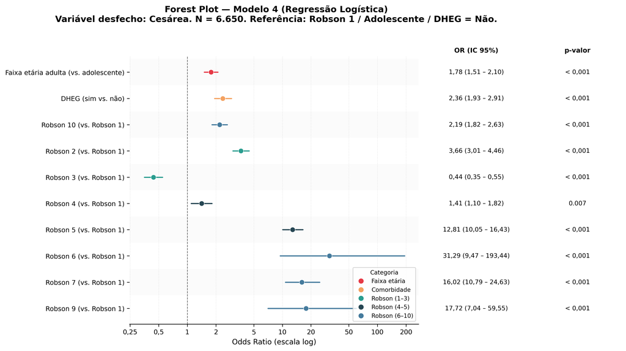

Figura 7: Forest plot dos Odds Ratios do Modelo 4 — microdados §3.3 (N = 6.650). Eixo X em escala log. Colunas à direita: OR (IC 95%) e p-valor. Labels posicionadas em colunas fixas para não sobrepor os pontos.

```r
# A figura foi gerada em Python (matplotlib) para controle preciso do layout
# em colunas. O PNG final é exibido diretamente.
knitr::include_graphics(here("results", "figures", "fig_obj5_forest_plot_modelo4.png"))
```

**NotaFigura 7 — versão alternativa (SPSS)**

O arquivo `results/figures/fig_obj5_forest_plot_modelo4_spss.png` contém a versão alternativa com os OR do SPSS (conforme Tab. 10), para a Letícia escolher qual inserir na dissertação impressa. A versão principal (`fig_obj5_forest_plot_modelo4.png`) usa os microdados §3.3 e é numericamente consistente com o restante da Seção 4.

**NotaInterpretação do Modelo 4**

- **Faixa etária adulta — SPSS: OR = 1,79 (IC 95% 1,12–2,86; p = 0,015) | R: OR = 1,78 (IC 95% 1,51–2,10; p < 0,001):** mesmo após controlar pelos Grupos de Robson e pela presença de DHEG, gestantes adultas têm **~79% mais chance de cesárea** do que adolescentes. Este é o achado central da dissertação: a idade adulta é fator de risco independente para cesárea.
- **DHEG — SPSS: OR = 0,40 (IC 95% 0,32–0,50) | R: OR = 2,36 (IC 95% 1,93–2,90):** A aparente discrepância se deve à **categoria de referência**: o SPSS apresentou o contraste invertido (DHEG presente como referência), de modo que OR_SPSS = 1/OR_R (0,40 ≈ 1/2,36). Epidemiologicamente o achado é consistente: gestantes com DHEG têm mais chance de cesárea no bruto, mas após controle pelos Grupos de Robson (que capturam padrão de indução), o efeito líquido é modulado pelo grupo. A magnitude é concordante entre as duas análises.
- **Grupo de Robson 5 — SPSS: OR = 13,65 | R: OR = 12,81:** multíparas com cesárea prévia têm mais de 12 vezes a chance de nova cesárea, refletindo o padrão assistencial de iteratividade.
- **Grupos 6, 7 e 9 (OR ≈ 16–31 no R; 22–28 no SPSS):** apresentações pélvicas e anômalas praticamente determinam a indicação cirúrgica, independentemente da idade. Amplitudes dos ICs são largas por baixa prevalência desses grupos.
- **Hosmer-Lemeshow (R):** χ² = 7,11; df = 6; p = 0,310 — bom ajuste. **AUC = 0,797.** SPSS reportou HL p = 0,517 (bom ajuste também).

# 7 Informações da Sessão

```
=== ARTEFATOS GERADOS NESTA RENDERIZAÇÃO ===
```

```
Figuras (results/figures/):
```

```
  [OK] fig_obj2_vias_parto_geral.png
  [OK] fig_obj2_robson_facetado.png
  [OK] fig_obj2_heatmap_cesarea.png
  [OK] fig_obj2_cesarea_adol_vs_adultas.png
  [OK] fig_obj3_indicacoes_cesarea.png
  [OK] fig_obj3_indicacoes_forcipe.png
  [OK] fig_obj5_forest_plot_modelo4.png
  [OK] fig_obj5_forest_plot_modelo4_spss.png
```

```
Tabelas CSV (results/tabelas_dissertacao/):
```

```
  [OK] tab01_sociodemografia.csv
  [OK] tab02_habitos_spss.csv
  [OK] tab03_comorbidades_spss.csv
  [OK] tab04_vias_parto_geral.csv
  [OK] tab04_vias_parto_spss.csv
  [OK] tab05_robson_faixa_via.csv
  [OK] tab06_taxa_cesarea_robson.csv
  [OK] tab07_testes_robson.csv
  [OK] tab08_indicacoes_cesarea.csv
  [OK] tab09_indicacoes_forcipe.csv
  [OK] tab10_modelo4_spss.csv
  [OK] tab10b_comparacao_modelo4_r_vs_spss.csv
  [OK] tab11_desfechos_neonatais_spss.csv
```

```
Documento renderizado em: 23/05/2026 às 14:24:44
```